# Exploring the HopFoehnTemp Data

Tino Schneidewind

2024-09-22

## Altdorf

Lets explore the data, and some descriptive statistics, its distribution, the time series etc. I will start of with **only the station Altdorf** as a placeholder for all individual stations.

### HOSPITALIZATIONS

**How are hospitalizations distributed over the year?** Hospitalisations rates are highest in winter and lowest in summer. This is the case for men, women and all age groups. However, divided by diseases, this pattern seems to be driven by cardiovascular and respiratory diseases.

**What are the yearly hospitalizations per age and disease?** Here again, we see the rising trend which is strongest in the age group 15-64. 0-14 year olds even have a slight decreasing trend while all other age group slightly increase in hospitalizations over time. Divided by disease groups, cardiovascular diseases show the steepest increase with its curve resembling the overall hospitalization trend quite well. All other disease show a small trend but are hard to distinguish from another. Again, the interpretation of the observed trends is limited by the unknown demographic development.

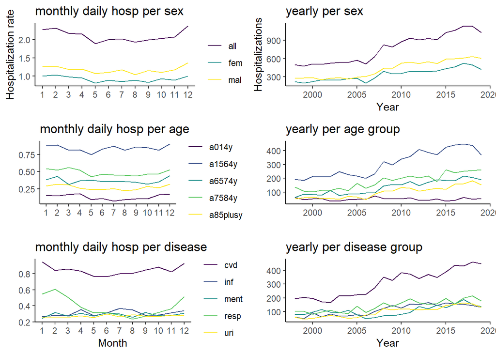

### FOEHN

**Is there a trend in annual foehn or seasonality?** We have a clear seasonal trend in foehn with a its peak in spring and intermediate levels in late autumn and winter. In summer there is only litte foehn on average per day. Over the observation period, foehn seems to decrease in its total occurence time per year. From the distribution (bottom left) it can be concluded, that on theoverarching majority of the days we have no foehn. Foehn frequency is antiproporional to its intensity, with a slight peak at 288 foehn score as this is the highest achievable for a day.

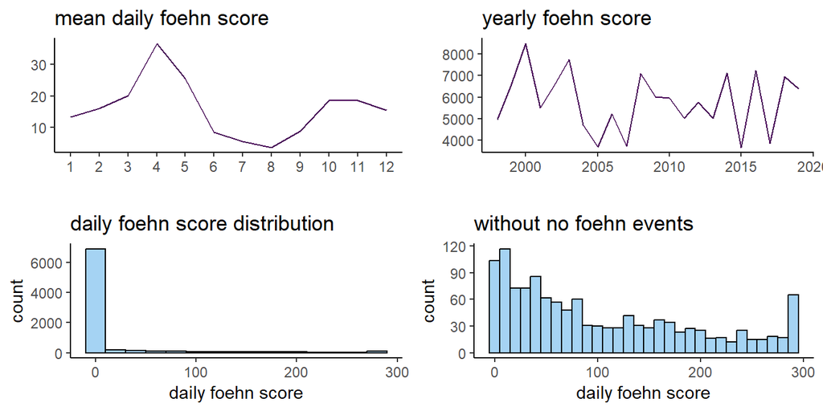

### TEMPERATURE

**Whats the annual path of temperature in Altdorf? Do we see an increasing trend of temperature?** As expected, it is warmest in summer with the highest monthly average in July just below 20 degrees C and coldest in winter just above 0 degrees. The yearly temperature trend has an increasing tendency. We see the hot years of 2003 and 2018 very clearly in Altdorf.

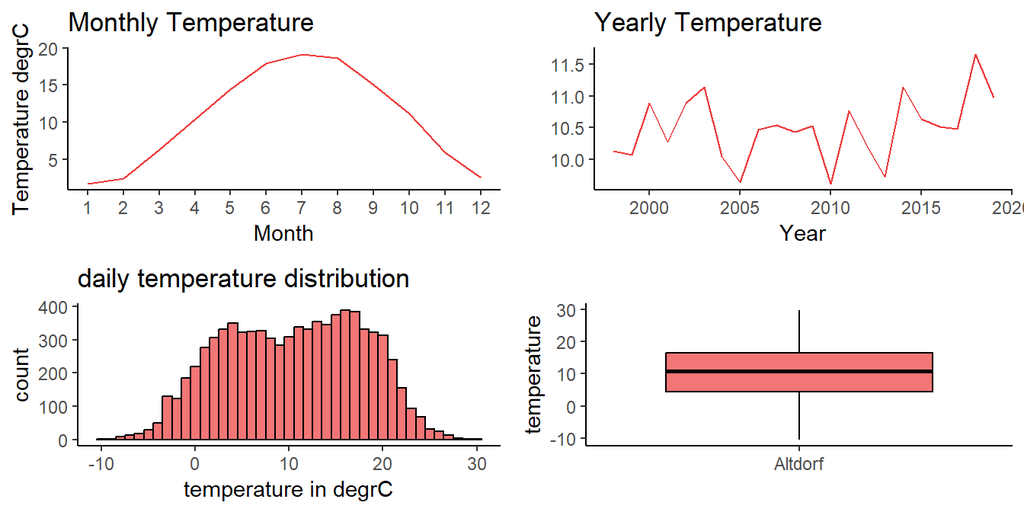

### CORRELATIONS

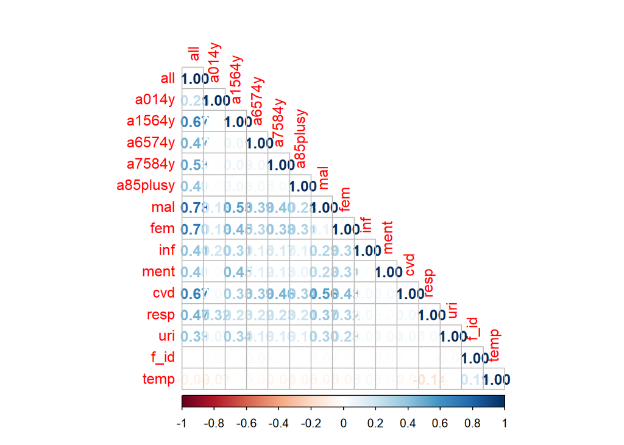